# Multivariate measurement error model in brms

Matthew Kay

2023-02-20

```r
library(tidyverse)
library(brms)
library(posterior)
library(ggdist)
theme_set(theme_ggdist())
options(mc.cores = parallel::detectCores())
```

# Generate data

We’ll generate some bivariate Normal data for two variables, `x1` and `x2`, with a known correlation (`true_cor`) and a known bias (`true_x2_bias`).

We’ll also generate “observations” of these variables, `x1_obs` and `x2_obs`, with measurement error `x1_sd` and `x2_sd`. i.e. we’re assuming we can’t observe `x1` or `x2` directly (so they won’t be in our model).

```r
set.seed(1234)

# reparameterize gamma dist in terms of mean and precision
# this will allow us to generate distributions of measurement error SDs
rgamma_mean_prec = function(n, mean, prec) rgamma(n, prec * mean / (mean + 1), prec / (mean + 1))

true_x2_bias = 0.1
true_cor = 0.6

df = MASS::mvrnorm(
  100,
  mu = c(x1 = 0, x2 = true_x2_bias),
  Sigma = matrix(c(1,true_cor,true_cor,1), nrow = 2)
) |>
  as_tibble() |>
  mutate(
    x1_sd = rgamma_mean_prec(n(), 0.2, 500),
    x1_obs = rnorm(n(), x1, x1_sd),
    # give x2 higher measurement error on average compared to x1, in analogy
    # to how adaptive will have higher measurement error
    x2_sd = rgamma_mean_prec(n(), 0.3, 500),
    x2_obs = rnorm(n(), x2, x2_sd)
  )
```

The first couple of rows of the data:

```r
head(df)
```

```
## # A tibble: 6 × 6
##       x1     x2 x1_sd x1_obs x2_sd x2_obs
##    <dbl>  <dbl> <dbl>  <dbl> <dbl>  <dbl>
## 1 -1.27  -0.794 0.210 -1.35  0.308 -0.609
## 2  0.460  0.136 0.214  0.271 0.305  0.331
## 3  0.940  1.10  0.203  1.24  0.275  0.718
## 4 -1.87  -2.22  0.214 -1.95  0.303 -2.57
## 5  0.753  0.114 0.206  1.00  0.317 -0.248
## 6  0.378  0.627 0.216  0.563 0.302  0.419
```

Plotted, with (unobservable) `x1` and `x2` as black squares and observed `x1_obs` and `x2_obs` as blue dots +/- 2*SD:

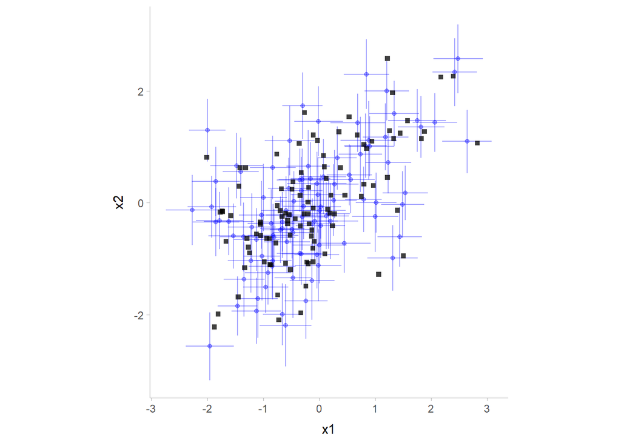

```r
df |>
  ggplot(aes(x1, x2)) +
  geom_point(aes(x1_obs, x2_obs), color = "blue", alpha = 0.35) +
  geom_linerange(aes(x = x1_obs, y = x2_obs, ymin = x2_obs - 2*x2_sd, ymax = x2_obs + 2*x2_sd), color = "blue", alpha = 0.35) +
  geom_linerange(aes(x = x1_obs, y = x2_obs, xmin = x1_obs - 2*x1_sd, xmax = x1_obs + 2*x1_sd), color = "blue", alpha = 0.35) +
  geom_point(alpha = 0.75, shape = "square") +
  coord_fixed()
```

A model of this data generating process is something like this:

$$\begin{align}
x_1^\textrm{obs} &\sim \operatorname{Normal}\left(x_1,
x_1^\textrm{sd}\right)\\
x_2^\textrm{obs} &\sim \operatorname{Normal}\left(x_2,
x_2^\textrm{sd}\right)\\
\begin{bmatrix}x_1 \\ x_2 \end{bmatrix} &\sim
\operatorname{MVN}\left(
\begin{bmatrix} \mu_1 \\ \mu_2 \end{bmatrix},
\begin{bmatrix} \sigma_1^2 & \sigma_1\rho\sigma_2 \\
\sigma_1\rho\sigma_2 & \sigma_2^2 \end{bmatrix}
\right)
\end{align}$$

Where $x_1$ and $x_2$ are unobserved, and $\rho$ (`true_cor`) is the correlation between $x_1$ and $x_2$. This looks a bit more complicated than our data generating process above, but that’s because we fixed $\mu_1 = 0$ so that $\mu_2$ could be the bias of $x_2$ relative to $x_1$ (`true_x2_bias`). We also fixed both $\sigma$s to be 1, which simplified the data generating process to this:

$$\begin{align}
\begin{bmatrix}x_1 \\ x_2 \end{bmatrix} &\sim
\operatorname{MVN}\left(
\begin{bmatrix} 0 \\ \mu_2 \end{bmatrix},
\begin{bmatrix} 1 & \rho \\ \rho & 1 \end{bmatrix}
\right)
\end{align}$$

However, we cannot assume those simplifications hold when fitting the model, so we estimate all those parameters from the data. The corresponding model written in brms syntax is:

```r
m_formula =
  bf(x1_obs | mi(x1_sd) ~ 1) +
  bf(x2_obs | mi(x2_sd) ~ 1) +
  set_rescor(TRUE)
```

For example, `x1_obs | mi(x1_sd)` defines a measurement error portion of the model, like $x_1^\textrm{obs} \sim \operatorname{Normal}\left(x_1, x_1^\textrm{sd}\right)$, and the combination of the two formulas with `+ set_rescor(TRUE)` tells brms to fit a multivariate model and estimate the residual correlation, defining the multivariate normal ($\operatorname{MVN}$) portion of the model.

Let’s check on priors:

```r
get_prior(m_formula, data = df)
```

```
##                    prior     class coef group  resp dpar nlpar lb ub  source
##                   (flat) Intercept                                   default
##                   lkj(1)    rescor                                   default
##  student_t(3, -0.3, 2.5) Intercept            x1obs                  default
##     student_t(3, 0, 2.5)     sigma            x1obs             0    default
##  student_t(3, -0.2, 2.5) Intercept            x2obs                  default
##     student_t(3, 0, 2.5)     sigma            x2obs             0    default
```

I’ll set some simple priors on this for the purposes of the example (should not just use these directly on the IRT stuff…)

```r
m_prior = c(
  prior(normal(0, 1), class = Intercept, resp = x1obs),
  prior(normal(0, 1), class = Intercept, resp = x2obs),
  prior(lkj(2), class = rescor),
  prior(normal(1, 1), class = sigma, resp = x1obs),
  prior(normal(1, 1), class = sigma, resp = x2obs)
)
```

And fit the model:

```r
m = brm(
  m_formula,
  prior = m_prior,
  backend = "cmdstanr",
  data = df
)
```

[output not shown]

[output cut: 43 more lines]

[output not shown]

Results look like this:

```r
m
```

```
##  Family: MV(gaussian, gaussian)
##   Links: mu = identity; sigma = identity
##          mu = identity; sigma = identity
## Formula: x1_obs | mi(x1_sd) ~ 1
##          x2_obs | mi(x2_sd) ~ 1
##    Data: df (Number of observations: 100)
##   Draws: 4 chains, each with iter = 2000; warmup = 1000; thin = 1;
##          total post-warmup draws = 4000
##
## Population-Level Effects:
##                 Estimate Est.Error l-95% CI u-95% CI Rhat Bulk_ESS Tail_ESS
## x1obs_Intercept    -0.16      0.11    -0.37     0.05 1.00     7276     2967
## x2obs_Intercept    -0.06      0.10    -0.26     0.15 1.00     7258     3076
##
## Family Specific Parameters:
##             Estimate Est.Error l-95% CI u-95% CI Rhat Bulk_ESS Tail_ESS
## sigma_x1obs     1.05      0.08     0.91     1.22 1.00     7863     3200
## sigma_x2obs     0.99      0.08     0.86     1.15 1.00     7304     3607
##
## Residual Correlations:
##                     Estimate Est.Error l-95% CI u-95% CI Rhat Bulk_ESS Tail_ESS
## rescor(x1obs,x2obs)     0.56      0.07     0.41     0.69 1.00     5880     3190
##
## Draws were sampled using sample(hmc). For each parameter, Bulk_ESS
## and Tail_ESS are effective sample size measures, and Rhat is the potential
## scale reduction factor on split chains (at convergence, Rhat = 1).
```

This gives us an estimate of the bias:

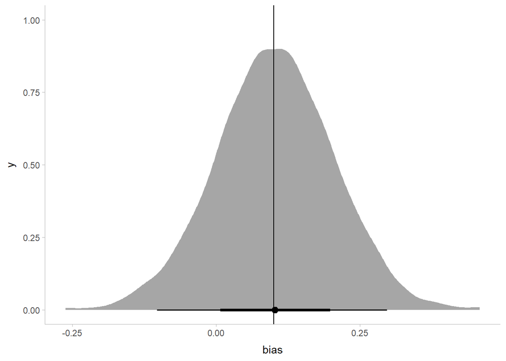

```r
m |>
  as_draws_df() |>
  mutate(bias = b_x2obs_Intercept - b_x1obs_Intercept) |>
  ggplot(aes(x = bias)) +
  stat_halfeye() +
  geom_vline(xintercept = true_x2_bias)
```

And an estimate of the correlation:

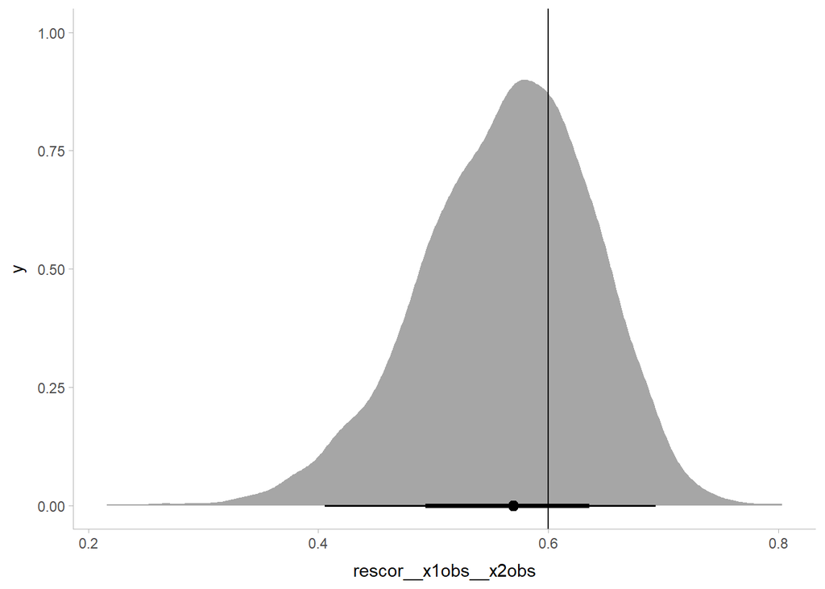

```r
m |>
  as_draws_df() |>
  ggplot(aes(x = rescor__x1obs__x2obs)) +
  stat_halfeye() +
  geom_vline(xintercept = true_cor)
```